# Final paper results Sept 24

Kristin Dobbin

2025-09-03

## Data overview

Our data set includes 4259 unique public water systems representing all of the active CWS and NTNCWS water systems in the same. Of these water systems 2811 are community water systems, 1448 are Non-Transient Non-Community systems. The mean population served by these systems is 9557.4444705.

## Describing carceral water systems

We classify these systems into three categories: Carceral water systems that primarily or exclusively serve carceral facilities; non-exclusive carceral water systems that serve one or more carceral facilities in addition to other customers and non-carceral systems that do not serve any carceral faciltiies. We find that 56 or 1.3148626% are carceral water systems. 151 or 3.5454332% are non-exclusive carceral systems and 4052 or 95.1397042% are noncarceral systems.

[output not shown]

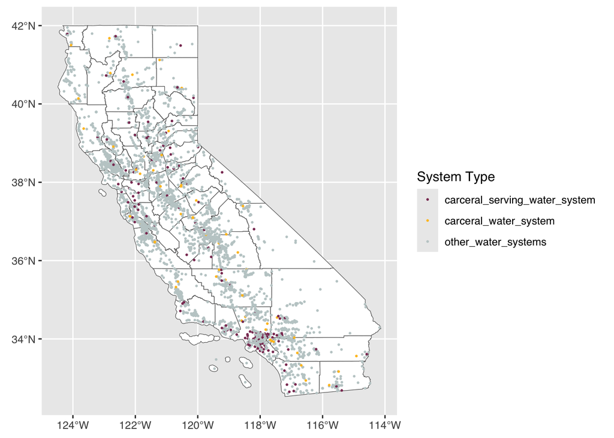